# R Notebook

# Data Pre-processing

Load needed libraries

```r
library(fastDummies)
library(readr)
library(ggplot2)
library(dplyr)
library(caret)
library(glmnet)
library(boot)
library(tree)
library(ranger)
library(xgboost)
library(gbm)
library(vip)
library(ISLR)
```

Set the seed for reproducibility

```r
set.seed(1)
```

Load the dataset

```r
original_lc_data <- read.csv("LCdata.csv",sep = ";")
lc_data <- original_lc_data
```

remove attributes not available for prediction

```r
lc_data <- subset(lc_data, select = -c(collection_recovery_fee, installment, issue_d,
                                       last_pymnt_amnt, last_pymnt_d, loan_status,
                                       next_pymnt_d, out_prncp, out_prncp_inv,
                                       pymnt_plan, recoveries, total_pymnt,
                                       total_pymnt_inv,total_rec_int, total_rec_late_fee,                                                  total_rec_prncp))
```

```r
summary(lc_data)
```

```
       id             member_id          loan_amnt      funded_amnt    funded_amnt_inv
 Min.   :   54734   Min.   :   70473   Min.   :  500   Min.   :  500   Min.   :    0
 1st Qu.: 9207230   1st Qu.:10877939   1st Qu.: 8000   1st Qu.: 8000   1st Qu.: 8000
 Median :34433372   Median :37095300   Median :13000   Median :13000   Median :13000
 Mean   :32463636   Mean   :35000265   Mean   :14754   Mean   :14741   Mean   :14702
 3rd Qu.:54900100   3rd Qu.:58470266   3rd Qu.:20000   3rd Qu.:20000   3rd Qu.:20000
 Max.   :68617057   Max.   :73544841   Max.   :35000   Max.   :35000   Max.   :35000

     term              int_rate      emp_title          emp_length        home_ownership
 Length:798641      Min.   : 5.32   Length:798641      Length:798641      Length:798641
 Class :character   1st Qu.: 9.99   Class :character   Class :character   Class :character
 Mode  :character   Median :12.99   Mode  :character   Mode  :character   Mode  :character
                    Mean   :13.24
                    3rd Qu.:16.20
                    Max.   :28.99

   annual_inc      verification_status     url                desc             purpose
 Min.   :      0   Length:798641       Length:798641      Length:798641      Length:798641
 1st Qu.:  45000   Class :character    Class :character   Class :character   Class :character
 Median :  65000   Mode  :character    Mode  :character   Mode  :character   Mode  :character
 Mean   :  75014
 3rd Qu.:  90000
 Max.   :9500000
 NA's   :4
    title             zip_code          addr_state             dti           delinq_2yrs
 Length:798641      Length:798641      Length:798641      Min.   :   0.00   Min.   : 0.0000
 Class :character   Class :character   Class :character   1st Qu.:  11.91   1st Qu.: 0.0000
 Mode  :character   Mode  :character   Mode  :character   Median :  17.66   Median : 0.0000
                                                          Mean   :  18.16   Mean   : 0.3145
                                                          3rd Qu.:  23.95   3rd Qu.: 0.0000
                                                          Max.   :9999.00   Max.   :39.0000
                                                                            NA's   :25
 earliest_cr_line   inq_last_6mths    mths_since_last_delinq mths_since_last_record
 Length:798641      Min.   : 0.0000   Min.   :  0.0          Min.   :  0.0
 Class :character   1st Qu.: 0.0000   1st Qu.: 15.0          1st Qu.: 51.0
 Mode  :character   Median : 0.0000   Median : 31.0          Median : 70.0
                    Mean   : 0.6947   Mean   : 34.1          Mean   : 70.1
                    3rd Qu.: 1.0000   3rd Qu.: 50.0          3rd Qu.: 92.0
                    Max.   :33.0000   Max.   :188.0          Max.   :129.0
                    NA's   :25        NA's   :408818         NA's   :675190
```

[output cut: 41 more lines]

```
 Min.   : 0.0     Min.   : 0       Min.   :    0    Min.   :  0.0    Min.   :      0
 1st Qu.: 0.0     1st Qu.: 1       1st Qu.: 2406    1st Qu.: 47.6    1st Qu.:  13900
 Median : 1.0     Median : 2       Median : 4502    Median : 61.9    Median :  23700
 Mean   : 1.4     Mean   : 3       Mean   : 5878    Mean   : 60.8    Mean   :  32093
 3rd Qu.: 2.0     3rd Qu.: 4       3rd Qu.: 7774    3rd Qu.: 75.2    3rd Qu.:  39800
 Max.   :22.0     Max.   :43       Max.   :83047    Max.   :151.4    Max.   :9999999
 NA's   :779525   NA's   :779525   NA's   :779525   NA's   :779525   NA's   :63276
     inq_fi        total_cu_tl      inq_last_12m
 Min.   : 0.0     Min.   : 0.0     Min.   :-4
 1st Qu.: 0.0     1st Qu.: 0.0     1st Qu.: 0
 Median : 0.0     Median : 0.0     Median : 2
 Mean   : 0.9     Mean   : 1.5     Mean   : 2
 3rd Qu.: 1.0     3rd Qu.: 2.0     3rd Qu.: 3
 Max.   :16.0     Max.   :35.0     Max.   :32
 NA's   :779525   NA's   :779525   NA's   :779525
```

First we delete the columns which aren’t useful for our prediction

```r
lc_data$id <- NULL
lc_data$member_id <- NULL
lc_data$zip_code <- NULL
lc_data$url <- NULL
```

Looks like **policy_code** contains just value equal to 1, it can be removed

```r
lc_data$policy_code <- NULL
```

Remove additional columns which are related to the historical data

```r
lc_data$last_credit_pull_d <- NULL
```

Then we delete the columns which can’t be converted to categorical and require NLP

```r
lc_data$title <- NULL
lc_data$desc <- NULL
lc_data$emp_title <- NULL
```

let’s examine the **loan_amnt** column

```r
sum(is.na(lc_data$loan_amnt))
```

```
[1] 0
```

```r
cor(lc_data$loan_amnt, lc_data$int_rate)
```

```
[1] 0.1447189
```

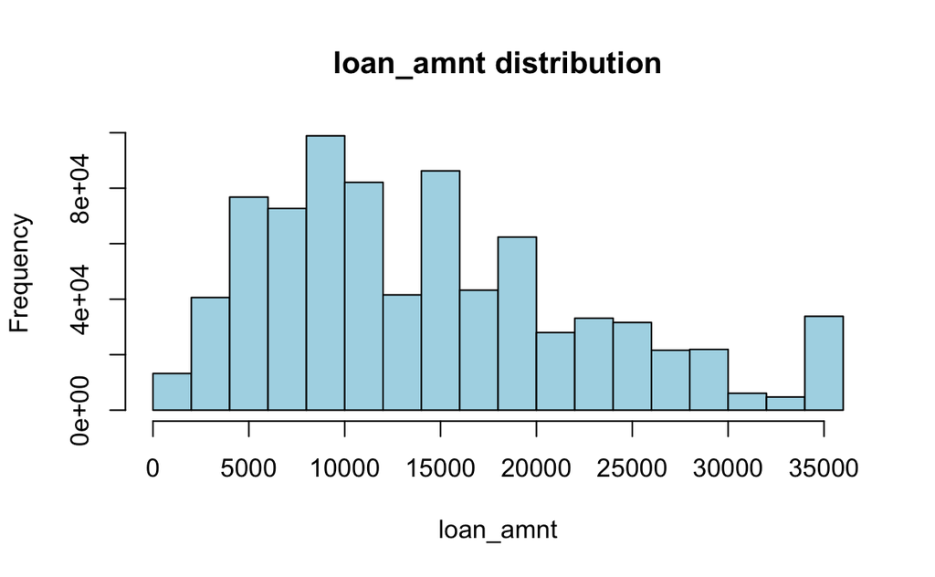

```r
hist(lc_data$loan_amnt, breaks = 20, main = "loan_amnt distribution", xlab = "loan_amnt", col = "lightblue", border = "black")
```

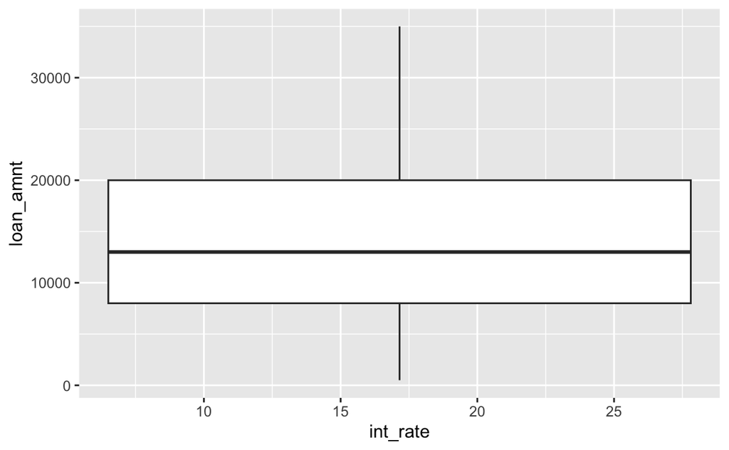

```r
ggplot(data = lc_data, mapping = aes(x=int_rate,y=loan_amnt)) + geom_boxplot()
```

standardize **loan_amnt**

```r
#lc_data$loan_amnt <- scale(lc_data$loan_amnt)
```

let’s examine the **funded_amnt** column

```r
sum(is.na(lc_data$funded_amnt))
```

```
[1] 0
```

```r
cor(lc_data$funded_amnt, lc_data$int_rate)
```

```
[1] 0.1448634
```

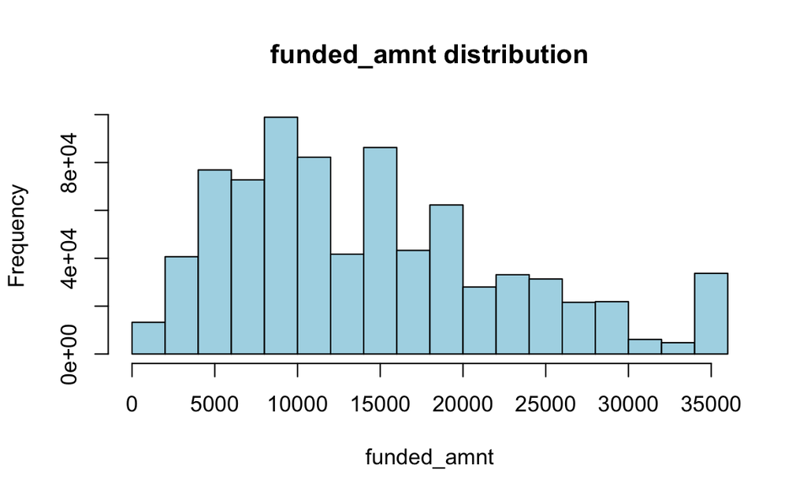

```r
hist(lc_data$funded_amnt, breaks = 20, main = "funded_amnt distribution", xlab = "funded_amnt", col = "lightblue", border = "black")
```

as we can see, **funded_amnt** is almost the same as the **loan_amnt** column, consequently, we remove it.

```r
lc_data$funded_amnt <- NULL
```

let’s examine the **funded_amnt_inv** column

```r
sum(is.na(lc_data$funded_amnt_inv))
```

```
[1] 0
```

```r
cor(lc_data$funded_amnt_inv, lc_data$int_rate)
```

```
[1] 0.1449083
```

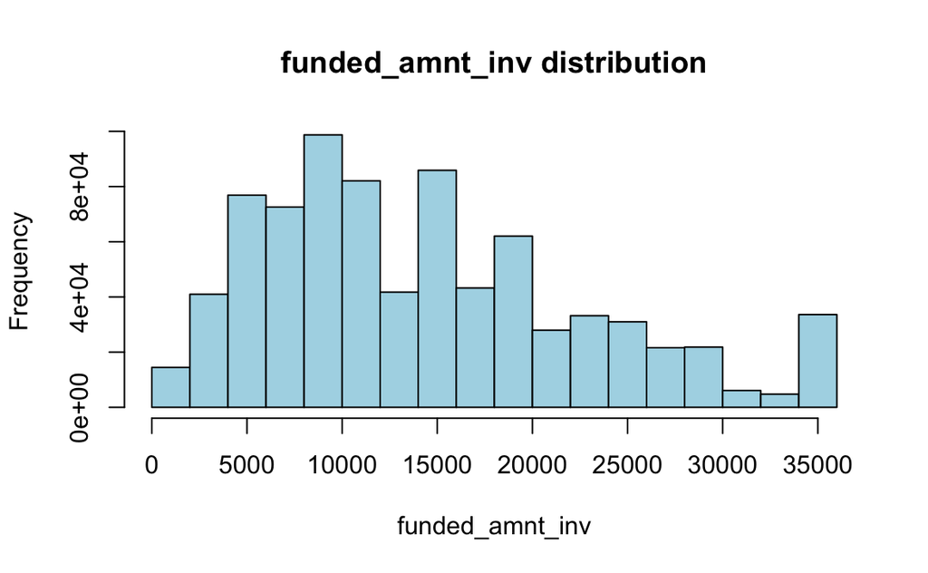

```r
hist(lc_data$funded_amnt_inv, breaks = 20, main = "funded_amnt_inv distribution", xlab = "funded_amnt_inv", col = "lightblue", border = "black")
```

remove **funded_amnt_inv** for the same reason as above

```r
lc_data$funded_amnt_inv <- NULL
```

let’s see the **int_rate** distribution.

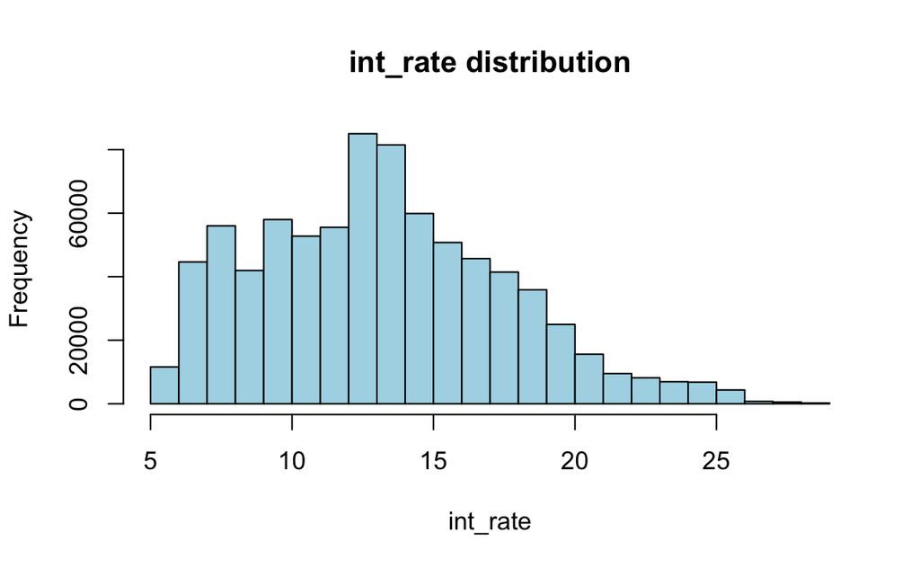

```r
hist(lc_data$int_rate, breaks = 20, main = "int_rate distribution", xlab = "int_rate", col = "lightblue", border = "black")
```

Standardize int rate:

```r
#lc_data$int_rate <- scale(lc_data$int_rate)
```

```r
n_distinct(lc_data$emp_title)
```

```
[1] 0
```

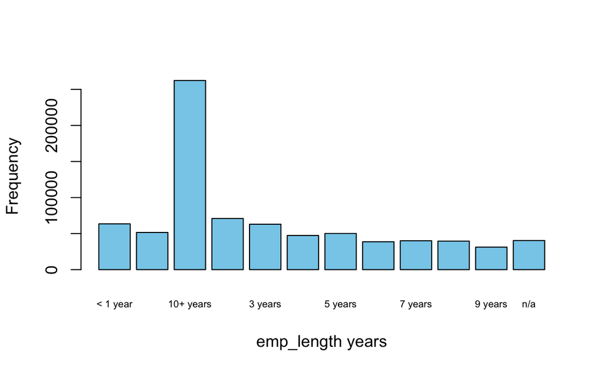

```r
barplot(table(lc_data$emp_length),
        xlab = "emp_length years",
        ylab = "Frequency",
        col = "skyblue",
        border = "black",
        cex.names = 0.6)  # The size of the main title
```

Since **emp_length** seems to be categorical, we transform it to as a factor and then as numeric. The conversion to numeric is needed for supporting the XGBoost

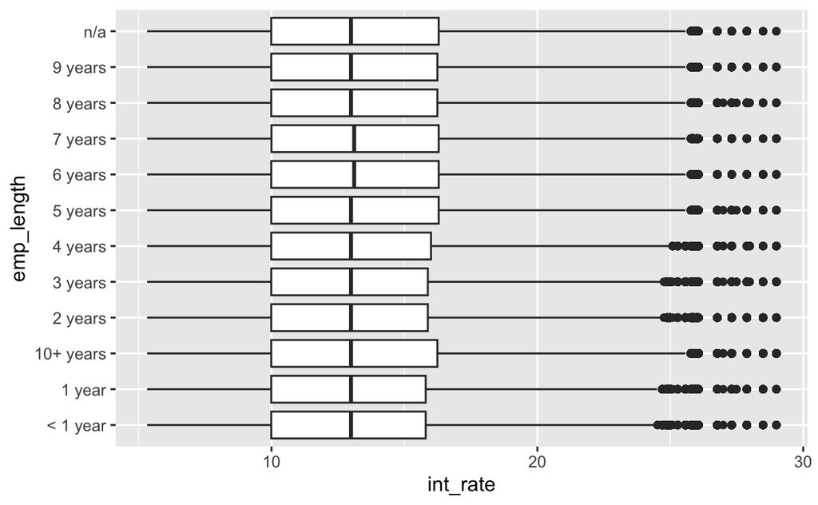

```r
lc_data$emp_length <- as.factor(lc_data$emp_length)
ggplot(data = lc_data, mapping = aes(x=int_rate,y=emp_length)) + geom_boxplot()
```

```r
lc_data$emp_length <- as.numeric(lc_data$emp_length)
```

**term**

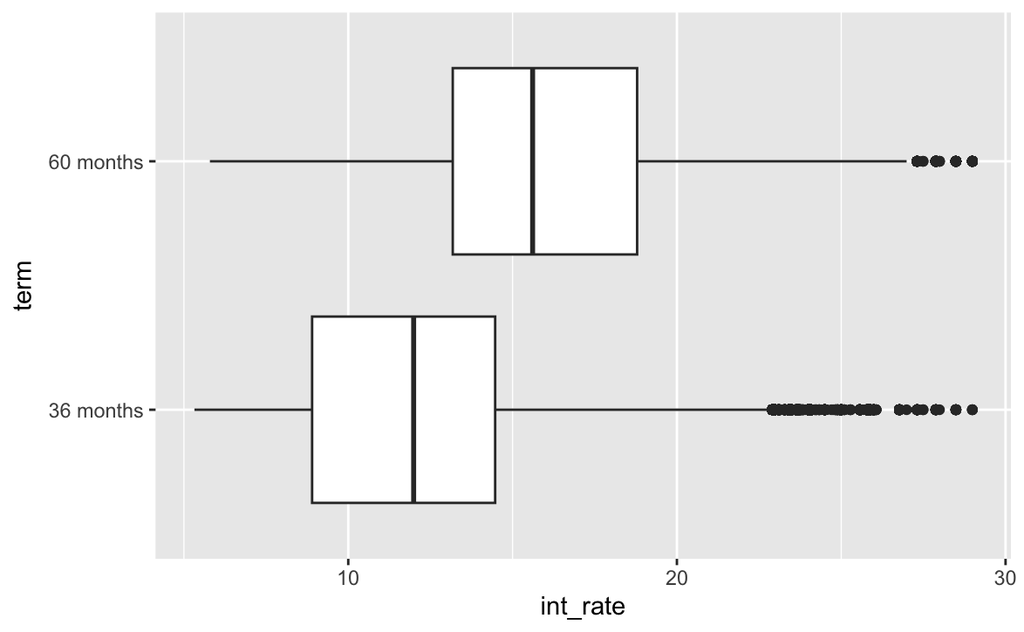

```r
lc_data$term <- as.factor(lc_data$term)
ggplot(data = lc_data, mapping = aes(x=int_rate,y=term)) + geom_boxplot()
```

```r
lc_data$term <- as.numeric(lc_data$term)
boh = order(lc_data$term)
```

Cleaning of **home_ownership**:

```r
table(lc_data$home_ownership)
```

```
     ANY MORTGAGE     NONE    OTHER      OWN     RENT
       2   399151       45      155    78789   320499
```

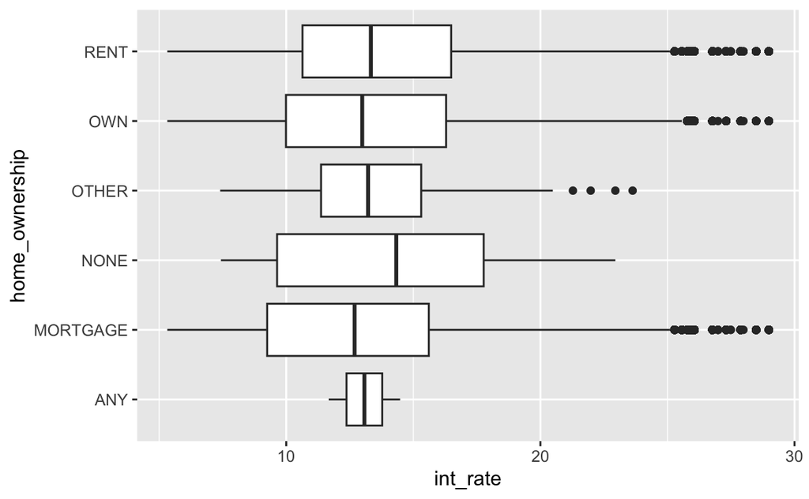

```r
ggplot(data = lc_data, mapping = aes(x=int_rate,y=home_ownership)) + geom_boxplot()
```

Then, we retain mortgage, own and rent:

```r
lc_data <- lc_data %>% filter(home_ownership %in% c("MORTGAGE","OWN","RENT"))
lc_data$home_ownership <- as.numeric(as.factor(lc_data$home_ownership))
```

# application joint handling

```r
# merging annual income
lc_data <- lc_data %>% mutate(
    annual_inc_merged = ifelse(is.na(annual_inc_joint)== TRUE, annual_inc,annual_inc_joint))

lc_data <- lc_data %>% select(-annual_inc,-annual_inc_joint)


# merging debt to income ratio
lc_data <- lc_data %>% mutate(
    dti_merged = ifelse(is.na(dti_joint)== TRUE, dti,dti_joint))

lc_data <- lc_data %>% select(-dti,-dti_joint)
```

Upon reviewing the summary again, it becomes apparent that there are merely 460 joint applications, constituting a small subset within the extensive dataset of around 800k rows. Through consolidating the debt-to-income ratios (dti’s), we can pinpoint the data pertinent to our research objectives. Hence, it is advisable to eliminate the columns verification_status_joint and application_type to prevent introducing unwarranted variability into our analysis.

```r
table(lc_data$verification_status)
```

```
   Not Verified Source Verified        Verified
         240255          296631          261553
```

```r
table(lc_data$verification_status_joint)
```

```
                   Not Verified Source Verified        Verified
         797979             253              53             154
```

```r
lc_data$verification_status <- as.numeric(as.factor(lc_data$verification_status))
lc_data <- lc_data %>% select(-verification_status_joint, -application_type)
```

Let’s checl if other is NA or a real value for purpose. It’s a real one, so we don’t have to handle it.

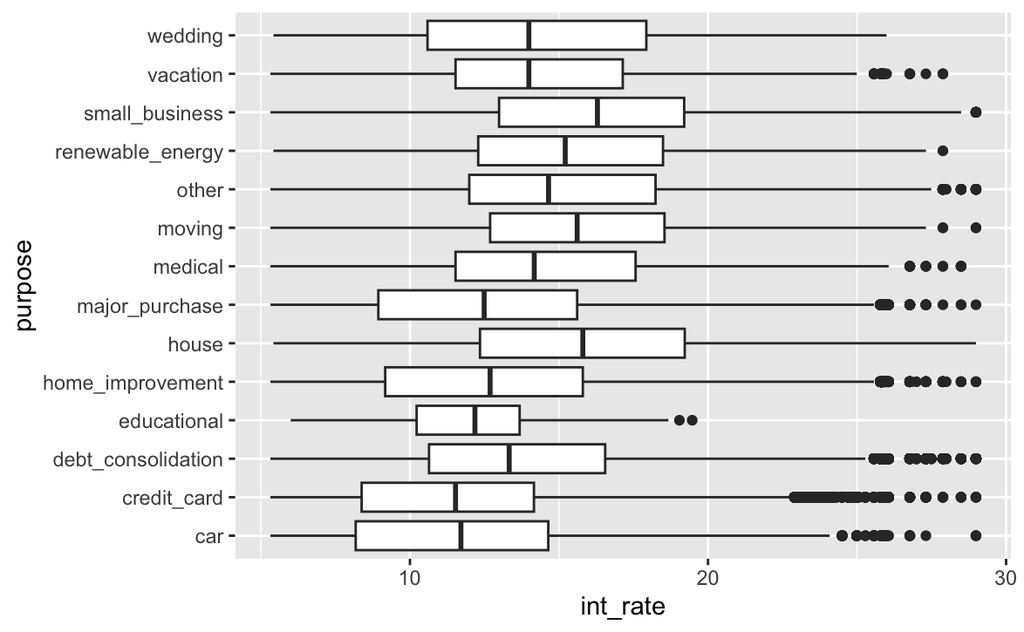

```r
lc_data$purpose <- as.factor(lc_data$purpose)
ggplot(data = lc_data, mapping = aes(x=int_rate,y=purpose)) + geom_boxplot()
```

```r
lc_data$purpose <- as.numeric(lc_data$purpose)
```

Let’s have a glance to the state address:

```r
table(lc_data$addr_state)
```

```
    AK     AL     AR     AZ     CA     CO     CT     DC     DE     FL     GA     HI     IA
  1992  10101   5953  18359 116578  16934  12154   2188   2268  54819  26146   4112     13
    ID     IL     IN     KS     KY     LA     MA     MD     ME     MI     MN     MO     MS
    11  31880  12393   7105   7726   9498  18546  18906    469  20678  14306  12821   3455
    MT     NC     ND     NE     NH     NJ     NM     NV     NY     OH     OK     OR     PA
  2286  22135    431   1064   3865  29991   4428  11155  66790  26682   7266   9806  28221
    RI     SC     SD     TN     TX     UT     VA     VT     WA     WI     WV     WY
  3499   9609   1615  11618  63982   5629  23616   1606  17470  10446   3977   1841
```

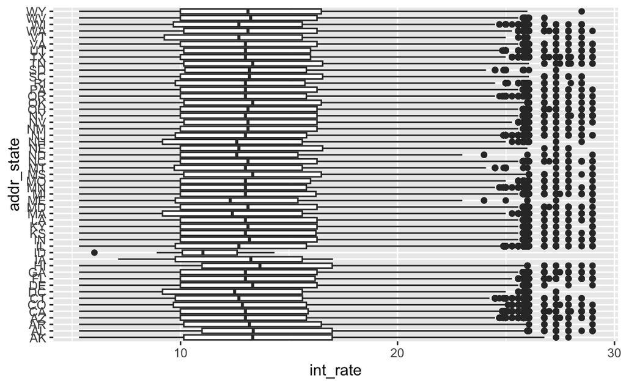

```r
lc_data$addr_state <- as.factor(lc_data$addr_state)
ggplot(data = lc_data, mapping = aes(x=int_rate,y=addr_state)) + geom_boxplot()
```

```r
lc_data$addr_state <- as.numeric(lc_data$addr_state)
```

Regarding delinquency in the last 2 years, there are few NAs then remove them:

```r
lc_data <- lc_data %>%
    filter(!(is.na(delinq_2yrs)))
```

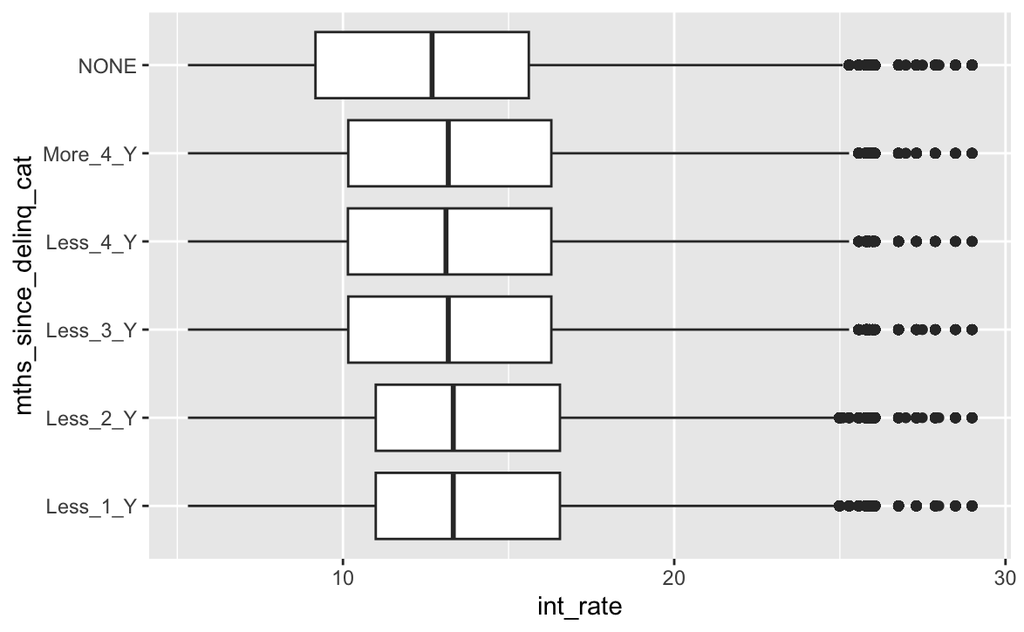

```r
lc_data <- lc_data %>%
  mutate(mths_since_delinq_cat = ifelse(
    is.na(mths_since_last_delinq) == TRUE,
    "NONE",
    ifelse(
      mths_since_last_delinq <= 12,
      "Less_1_Y",
      ifelse(
        mths_since_last_delinq <= 24,
        "Less_2_Y",
        ifelse(
          mths_since_last_delinq <= 36,
          "Less_3_Y",
          ifelse(mths_since_last_delinq <= 48, "Less_4_Y", "More_4_Y")
        )
      )
    )
  )) %>% select(-mths_since_last_delinq)

lc_data$mths_since_delinq_cat <- as.factor(lc_data$mths_since_delinq_cat)
ggplot(data = lc_data, mapping = aes(x=int_rate,y=mths_since_delinq_cat))+geom_boxplot()
```

```r
lc_data$mths_since_delinq_cat <- as.numeric(lc_data$mths_since_delinq_cat)
```

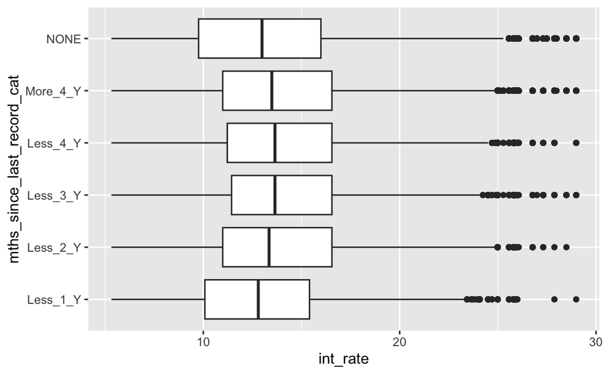

```r
lc_data <- lc_data %>%
  mutate(mths_since_last_record_cat = ifelse(
    is.na(mths_since_last_record) == TRUE,
    "NONE",
    ifelse(
      mths_since_last_record <= 12,
      "Less_1_Y",
      ifelse(
        mths_since_last_record <= 24,
        "Less_2_Y",
        ifelse(
          mths_since_last_record <= 36,
          "Less_3_Y",
          ifelse(mths_since_last_record <= 48, "Less_4_Y", "More_4_Y")
        )
      )
    )
  )) %>% select(-mths_since_last_record)

lc_data$mths_since_last_record_cat <- as.factor(lc_data$mths_since_last_record_cat)
ggplot(data = lc_data, mapping = aes(x=int_rate,y=mths_since_last_record_cat))+geom_boxplot()
```

```r
lc_data$mths_since_last_record_cat <- as.numeric(lc_data$mths_since_last_record_cat)
```

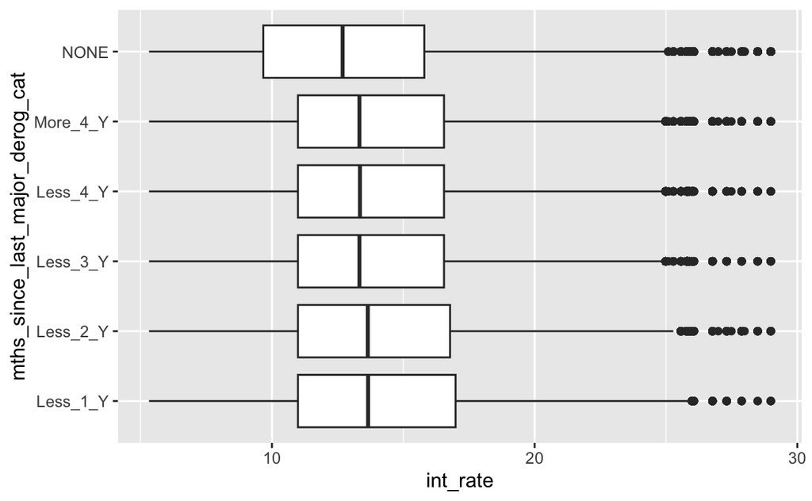

```r
lc_data <-lc_data %>%
  mutate(mths_since_last_major_derog_cat =  ifelse(
    is.na(mths_since_last_major_derog) == TRUE,
    "NONE",
    ifelse(
      mths_since_last_major_derog <= 12,
      "Less_1_Y",
      ifelse(
        mths_since_last_major_derog <= 24,
        "Less_2_Y",
        ifelse(
          mths_since_last_major_derog <= 36,
          "Less_3_Y",
          ifelse(mths_since_last_major_derog <= 48, "Less_4_Y", "More_4_Y")
        )
      )
    )
  )) %>% select(-mths_since_last_major_derog)

lc_data$mths_since_last_major_derog_cat <- as.factor(lc_data$mths_since_last_major_derog_cat)
ggplot(data = lc_data, mapping = aes(x=int_rate,y=mths_since_last_major_derog_cat))+geom_boxplot()
```

```r
lc_data$mths_since_last_major_derog_cat <- as.numeric(lc_data$mths_since_last_major_derog_cat)
```

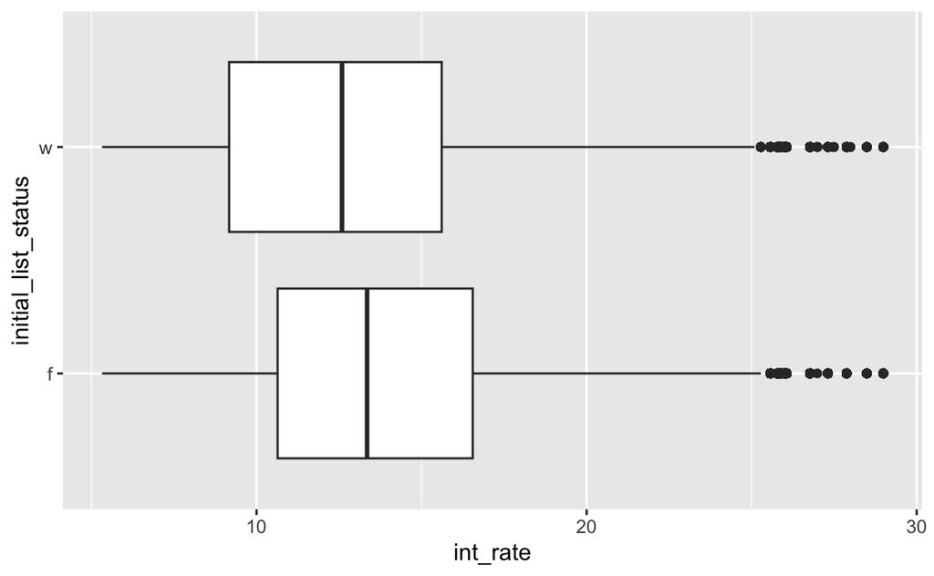

```r
lc_data$initial_list_status <- as.factor(lc_data$initial_list_status)
ggplot(data = lc_data, mapping = aes(x=int_rate,y=initial_list_status))+geom_boxplot()
```

```r
lc_data$initial_list_status <- as.numeric(lc_data$initial_list_status)
```

Let’s check which columns still have null values

```r
colSums(is.na(lc_data))
```

```
                      loan_amnt                            term                        int_rate
                              0                               0                               0
                     emp_length                  home_ownership             verification_status
                              0                               0                               0
                        purpose                      addr_state                     delinq_2yrs
                              0                               0                               0
               earliest_cr_line                  inq_last_6mths                        open_acc
                              0                               0                               0
                        pub_rec                       revol_bal                      revol_util
                              0                               2                             428
                      total_acc             initial_list_status      collections_12_mths_ex_med
                              0                               0                              99
                 acc_now_delinq                    tot_coll_amt                     tot_cur_bal
                              0                           63132                           63132
                    open_acc_6m                      open_il_6m                     open_il_12m
                         779302                          779302                          779302
                    open_il_24m              mths_since_rcnt_il                    total_bal_il
                         779302                          779807                          779302
                        il_util                     open_rv_12m                     open_rv_24m
                         781784                          779302                          779302
                     max_bal_bc                        all_util                total_rev_hi_lim
                         779302                          779302                           63132
                         inq_fi                     total_cu_tl                    inq_last_12m
                         779302                          779302                          779302
              annual_inc_merged                      dti_merged           mths_since_delinq_cat
                              0                               0                               0
     mths_since_last_record_cat mths_since_last_major_derog_cat
                              0                               0
```

The columns **revol_bal** and **revol_util** contain only few NA values, those values can’t be replaced with 0, then we filter the values which are not NA

```r
lc_data <- lc_data %>%
    filter(!(is.na(revol_bal))) %>%
        filter(!(is.na(revol_util)))
```

Let’s check which columns still have null values

```r
names(which(colSums(is.na(lc_data)) > 0))
```

```
 [1] "collections_12_mths_ex_med" "tot_coll_amt"               "tot_cur_bal"
 [4] "open_acc_6m"                "open_il_6m"                 "open_il_12m"
 [7] "open_il_24m"                "mths_since_rcnt_il"         "total_bal_il"
[10] "il_util"                    "open_rv_12m"                "open_rv_24m"
[13] "max_bal_bc"                 "all_util"                   "total_rev_hi_lim"
[16] "inq_fi"                     "total_cu_tl"                "inq_last_12m"
```

Replace null values with 0 where is possible

```r
lc_data <-
  lc_data %>%
  mutate(open_acc_6m = ifelse(is.na(open_acc_6m) == TRUE, 0, open_acc_6m)) %>%
  mutate(tot_cur_bal = ifelse(is.na(tot_cur_bal) == TRUE, 0, tot_cur_bal)) %>%
  mutate(open_il_6m = ifelse(is.na(open_il_6m) == TRUE, 0, open_il_6m)) %>%
  mutate(open_il_12m = ifelse(is.na(open_il_12m) == TRUE, 0, open_il_12m)) %>%
  mutate(open_il_24m = ifelse(is.na(open_il_24m) == TRUE, 0, open_il_24m)) %>%
  mutate(mths_since_rcnt_il = ifelse(is.na(mths_since_rcnt_il) == TRUE, 0, mths_since_rcnt_il)) %>%
  mutate(total_bal_il = ifelse(is.na(total_bal_il) == TRUE, 0, total_bal_il)) %>%
  mutate(il_util = ifelse(is.na(il_util) == TRUE, 0, il_util)) %>%
  mutate(open_rv_12m = ifelse(is.na(open_rv_12m) == TRUE, 0, open_rv_12m)) %>%
  mutate(total_rev_hi_lim = ifelse(is.na(total_rev_hi_lim) == TRUE, 0, total_rev_hi_lim)) %>%
  mutate(max_bal_bc = ifelse(is.na(max_bal_bc) == TRUE, 0, max_bal_bc)) %>%
  mutate(all_util = ifelse(is.na(all_util) == TRUE, 0, all_util)) %>%
  mutate(inq_fi = ifelse(is.na(inq_fi) == TRUE, 0, inq_fi)) %>%
  mutate(total_cu_tl = ifelse(is.na(total_cu_tl) == TRUE, 0, total_cu_tl)) %>%
  mutate(inq_last_12m = ifelse(is.na(inq_last_12m) == TRUE, 0, inq_last_12m)) %>%
  mutate(open_rv_24m = ifelse(is.na(open_rv_24m) == TRUE, 0, open_rv_24m)) %>%
  mutate(tot_coll_amt = ifelse(is.na(tot_coll_amt)== TRUE,0, tot_coll_amt)) %>%
  mutate(collections_12_mths_ex_med = ifelse(is.na(collections_12_mths_ex_med)== TRUE,0, collections_12_mths_ex_med))
```

**earliest_cr_line** contains the month the borrower’s earliest reported credit line was opened. Even if this date consists only on month and year, still there are too many unique values. We could transform the dates in to a numerical value, by converting them from date into Unix Time. This unit measures time by the number of seconds that have elapsed since 00:00:00 UTC on 1 January 1970. Since this column doesn’t contain the day number, we take as a reference the first day of the month.

```r
lc_data <- lc_data %>%
    filter(!(is.na(earliest_cr_line)))

# function to replace dates with unix time
to_unix_time <- function(date) {
  tmp <- paste("01", date, sep="-")
  return (as.numeric(as.POSIXct(tmp, format="%d-%b-%Y", tz="UTC")))
}

# map dates to unix time
lc_data$earliest_cr_line <- apply(lc_data, 1, function(row) to_unix_time(row["earliest_cr_line"]))

# standardize them
#lc_data$earliest_cr_line <- scale(lc_data$earliest_cr_line)
```

Outliers Removal.

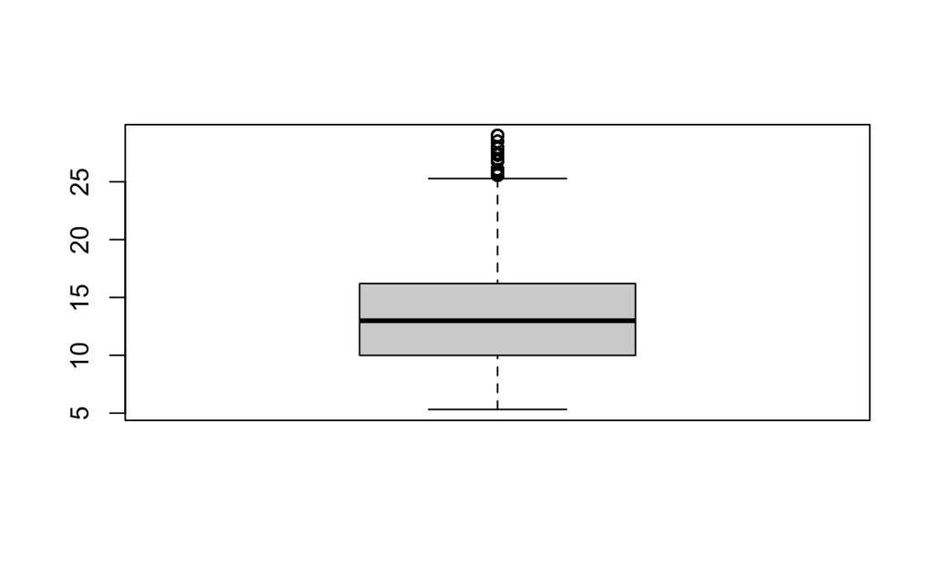

```r
boxplot(lc_data$int_rate)
```

```r
# Identify outliers using boxplot
outliers <- boxplot(lc_data$int_rate, plot = FALSE)$out
# Remove outliers from the dataset
lc_data_clean <- lc_data[!lc_data$int_rate %in% outliers, ]
```